# Data

2026 DRC Bundibugyo virus outbreak — sources, extraction, and what reconciles

**NoteMostly written by AI**

Most of the text on this site, and most of the code behind it, was written by Anthropic’s Claude Code agents working under my direction. The outbreak produces a new situation report every day, and I wanted this data out fast and kept current, which I couldn’t have done by hand. The numbers are computed by the pipeline and checked against the reports ([here’s how](https://vsbuffalo.github.io/ebola-bdbv-data/engineering.html)), but the writing was done in a hurry and will have mistakes. If you find one, please [open an issue](https://github.com/vsbuffalo/ebola-bdbv-data/issues) or get in touch. — Vince Buffalo

## What’s here

The data on this page come from the situation reports (“sitreps”) that INSP, the DRC’s national public health institute, publishes on the outbreak. The reports count cases by health zone, the district-sized unit the country’s health system is organised into, and health zones roll up into provinces.

Every number and every figure on this page is read from a file the pipeline builds, at the moment the page renders. If a figure has no build rule behind it, or a file hasn’t been built yet, the render stops with an error, so nothing here can be typed in by hand or left over from an old build. To rebuild it all yourself, run `make build`, `make streams`, `make figures` and `make compare`.

The archive holds **161 situation reports** (through 2026-10-29). **151** are read at health-zone level — every report that prints a per-zone table — for **7,396** zone-day rows; the provincial summary covers 146 reports, and three early reports are read from their own prose. Every held report contributes case data at the finest level its pages print.

```
'data/build/figures/latest/availability.png'
```

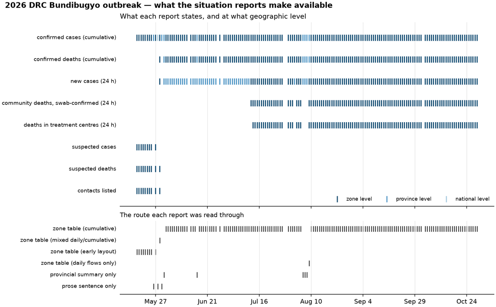

What each report states, at what geographic level (country, province or health zone), and which table layout I read it through.

The reports annotate their own early numbers, and I treat those annotations as data. Nearly every report from 004 through 033 carries a footnote saying its headline cumulative count is still being harmonised, that is, reconciled across the levels of the health system. From sitrep 026 (9 June) the footnote also says which way the error runs. The count leaves out confirmed cases who are still in the community and patients who escaped from care, so it is too low. Sitreps 011 and 012 have a footnote saying the death count itself is underestimated. Later, from sitrep 060 to 083, the reports warn that the last few days’ changes should be read with caution, because notifications arrive late and the data are still being consolidated. Each of these statements is a row in `provisional_caveat.csv`, whose `kind` column says which sort of caveat it is: `harmonisation_pending` (still being harmonised), `harmonisation_undercount` (being harmonised, and stated to be too low), `deaths_underestimated`, or `recent_data_provisional` (the warning about recent days, flagged “caveat” in the index). The index below flags them report by report. This matters if you fit the first four weeks of the outbreak, because you’d be fitting numbers the source itself called provisional, and from 9 June called too low.

## Index of situation reports

One row per report. *Route* is the table layout it was read through (`—` when no zone table exists); *identity* asks whether the page’s own arithmetic closes; *flags* mark the source’s own provisionality caveat, a hand-verified exception, or a rejected route.

Table 1: Index of situation reports

| report | date | route | rows | identity | residual | flags |
| --- | --- | --- | --- | --- | --- | --- |
| 001 | 2026-05-14 | — | 0 | — |  |  |
| 002 | 2026-05-17 | — | 0 | — |  |  |
| 004 | 2026-05-18 | zone_early | 8 | ok | 0 | harmonisation |
| 005 | 2026-05-19 | zone_early | 8 | ok | 0 | harmonisation |
| 006 | 2026-05-20 | zone_early | 10 | ok | 0 | harmonisation |
| 007 | 2026-05-21 | zone_early | 13 | ok | 0 | harmonisation |
| 008 | 2026-05-22 | zone_early | 13 | ok | 0 | harmonisation |
| 009 | 2026-05-23 | zone_early | 14 | ok | 0 | harmonisation |
| 010 | 2026-05-24 | zone_early | 18 | ok | 0 | harmonisation |
| 011 | 2026-05-25 | zone_early | 18 | ok | 0 | harmonisation, deaths understated |
| 012 | 2026-05-26 | — | 0 | — |  | deaths understated |
| 013 | 2026-05-27 | zone_early | 21 | ok | 0 | harmonisation |
| 014 | 2026-05-28 | — | 0 | — |  |  |
| 015 | 2026-05-29 | zone_mixed | 31 | ok | 0 |  |
| 016 | 2026-05-30 | — | 0 | — |  | harmonisation |
| 017 | 2026-05-31 | — | 0 | — |  | harmonisation |
| 018 | 2026-06-01 | zone_cumulative | 29 | ok | 0 | harmonisation |
| 019 | 2026-06-02 | zone_cumulative | 30 | ok | 0 | harmonisation |
| 020 | 2026-06-03 | zone_cumulative | 30 | ok | 0 | harmonisation |
| 021 | 2026-06-04 | zone_cumulative | 30 | ok | 0 | harmonisation |
| 022 | 2026-06-05 | zone_cumulative | 30 | ok | 0 | harmonisation |
| 023 | 2026-06-06 | zone_cumulative | 30 | ok | 0 | harmonisation |
| 024 | 2026-06-07 | zone_cumulative | 30 | ok | 0 | harmonisation |
| 025 | 2026-06-08 | zone_cumulative | 30 | ok | 0 | harmonisation |
| 026 | 2026-06-09 | zone_cumulative | 31 | ok | 0 | stated undercount |
| 027 | 2026-06-10 | zone_cumulative | 34 | ok | 0 | stated undercount |
| 028 | 2026-06-11 | zone_cumulative | 34 | ok | 0 | stated undercount |
| 030 | 2026-06-13 | zone_cumulative | 36 | ok | 0 | stated undercount |
| 031 | 2026-06-14 | zone_cumulative | 36 | ok | 0 | stated undercount |
| 032 | 2026-06-15 | zone_cumulative | 36 | ok | 0 | stated undercount |

[output cut: 131 more lines]

## One primary source, and two readings I only check against

The primary source is the set of situation-report PDFs that INSP (Institut National de Santé Publique) posts at `insp.cd`. I download them and pin each one with a committed index and a manifest of SHA-256 hashes, so I can tell if a file ever changes. Then I read the numbers from the table geometry drawn in the PDF itself.

Two other groups have read the same documents. INRB-UMIE, the national laboratory, keeps its own transcription, and epiforecasts has a scan. I use both only as checks; nothing on this page is built from them. Since all three of us read the same pages, agreement between us tells you the transcription is right. It tells you nothing about whether the counts themselves are right. A disagreement, on the other hand, always means something: either one of the readings has an error, or two versions of a revised report were read.

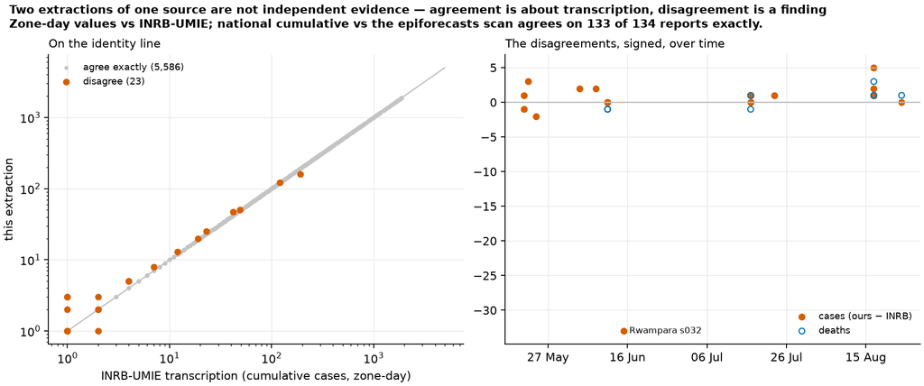

Our values plotted against INRB-UMIE’s, with the line where the two would be equal, and each disagreement over time with its sign.

```
'data/build/figures/latest/comparison_series.png'
```

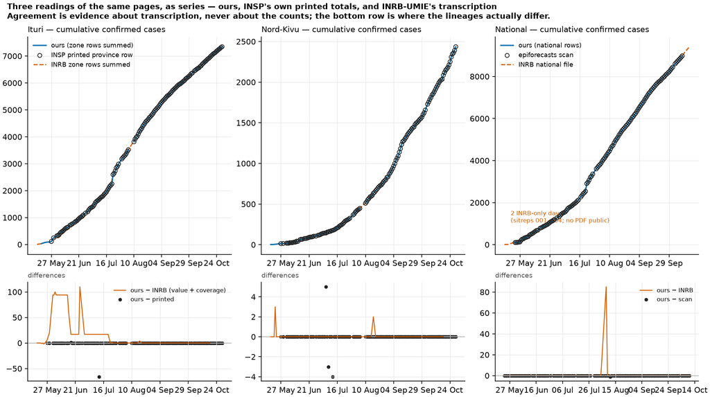

## Every table is checked against the page’s own arithmetic

Every table I extract has to add up the way the page says it does. A province’s health-zone rows, plus any rows the source counts but hasn’t assigned to a zone yet, must equal the province total printed on the page, and the provinces must add up to the printed national total. When they don’t, I assume the mistake is mine until reading the page shows otherwise.

Sometimes the page really doesn’t add up. When that happens the judgement goes into a register, a hand-kept file with one row per judgement. Each row is tied to the SHA-256 hash of that exact PDF, and it excuses that one gap on that one document and nothing else.

Province-reports: **767 reconcile exactly**, 10 carry a hand-verified exception (the page disagrees with itself, read and recorded), 0 disagree and remain open, 30 print no total to check against.

This check has a blind spot. It only catches errors that break the arithmetic. If I read the neighbouring column of a table by mistake, say suspected cases instead of confirmed, that column adds up just as well, and the check passes. Mistakes like that get caught another way: by tests that pin the values of specific named reports, and by comparing the assembled series against the printed totals, further down.

## The series

```
'data/build/figures/latest/province_series.png'
```

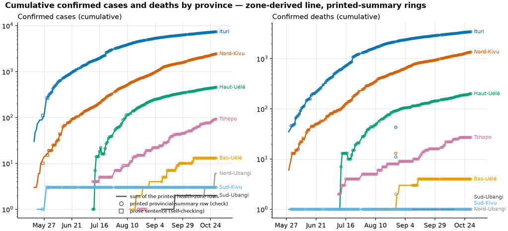

Cumulative confirmed cases and deaths by province. The line is the sum of the health-zone rows the reports print. Rings are the values in the printed provincial summary, shown as a check. Squares are values read from sentences in the report text, which carry their own internal check.

```
'data/build/figures/latest/streams_detail.png'
```

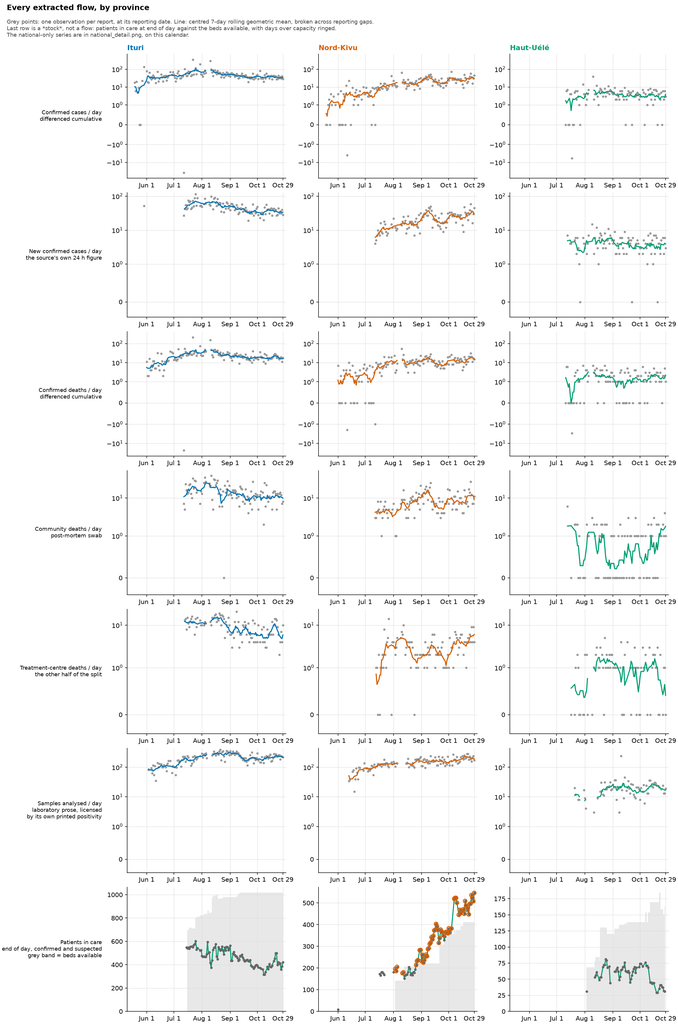

Every daily flow I extract, by province. The reports that carried the source’s warning that recent data were still being consolidated aren’t marked here, but every daily stream file has a `consolidating` column that says which they are.

```
'data/build/figures/latest/national_detail.png'
```

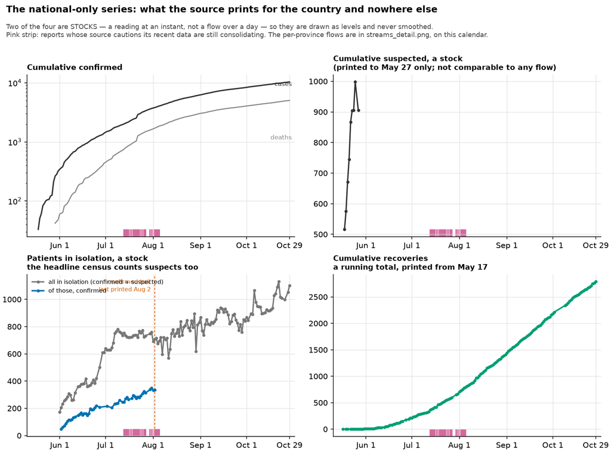

The four series the source prints only for the whole country, never by province. Two of them are stocks: each value is a reading taken at one moment, like the number of patients in isolation that day, rather than a count accumulated over a day. So they’re drawn as levels and never smoothed. The calendar matches the panel above.

The streams that downstream models fit are weekly incidence per province. To build them I take the cumulative count, carry the last known value forward over days with no report, difference it, and bin the differences into weeks counted from day 0 (2026-05-19). Two checks have to pass. The total a stream emits has to equal exactly how far the cumulative count moved, and the assembled grid is compared against every province row the reports print.

Table 2: Stream reconciliation. *vs source Δ* must be zero by construction; *grid = printed* counts report dates where the assembled cumulative equals the printed province row, and the *final gap* is the difference on the last report — zero for every stream.

| stream | obs | emitted | vs source Δ | grid = printed | final gap |
| --- | --- | --- | --- | --- | --- |
| `cases_bas_uele` | 12 | 12 | 0 | 78/78 | +0 |
| `cases_daily_bas_uele` | 77 | 12 | 0 | — | — |
| `cases_daily_haut_uele` | 104 | 452 | 0 | — | — |
| `cases_daily_ituri` | 148 | 7,316 | 0 | — | — |
| `cases_daily_national` | 158 | 10,318 | 0 | — | — |
| `cases_daily_nord_kivu` | 149 | 2,433 | 0 | — | — |
| `cases_daily_nord_ubangi` | 13 | 4 | 0 | — | — |
| `cases_daily_sud_kivu` | 146 | 2 | 0 | — | — |
| `cases_daily_sud_ubangi` | 48 | 1 | 0 | — | — |
| `cases_daily_tshopo` | 104 | 88 | 0 | — | — |
| `cases_haut_uele` | 17 | 452 | 0 | 105/105 | +0 |
| `cases_ituri` | 25 | 7,316 | 0 | 140/142 | +0 |
| `cases_national` | 25 | 10,318 | 0 | — | — |
| `cases_nord_kivu` | 25 | 2,433 | 0 | 139/142 | +0 |
| `cases_nord_ubangi` | 3 | 4 | 0 | 14/14 | +0 |
| `cases_sud_kivu` | 24 | 2 | 0 | 142/142 | +0 |
| `cases_sud_ubangi` | 8 | 1 | 0 | 49/49 | +0 |
| `cases_tshopo` | 17 | 88 | 0 | 105/105 | +0 |
| `community_deaths_bas_uele` | 12 | 3 of 4 | — | 12/12 daily | — |
| `community_deaths_daily_bas_uele` | 78 | 3 of 4 | — | 0 flagged | — |
| `community_deaths_daily_haut_uele` | 93 | 84 of 176 | — | 13 flagged | — |
| `community_deaths_daily_ituri` | 102 | 1,499 of 2,478 | — | 21 flagged | — |
| `community_deaths_daily_national` | 102 | 2,465 of 3,859 | — | 21 flagged | — |
| `community_deaths_daily_nord_kivu` | 102 | 867 of 1,177 | — | 21 flagged | — |
| `community_deaths_daily_nord_ubangi` | 14 | 1 of 1 | — | 0 flagged | — |
| `community_deaths_daily_sud_kivu` | 86 | 8 of 22 | — | 6 flagged | — |
| `community_deaths_daily_sud_ubangi` | 49 | 1 of 1 | — | 0 flagged | — |
| `community_deaths_daily_tshopo` | 85 | 10 of 22 | — | 5 flagged | — |
| `community_deaths_haut_uele` | 17 | 84 of 176 | — | 77/89 daily | — |
| `community_deaths_ituri` | 17 | 1,499 of 2,478 | — | 41/101 daily | — |
| `community_deaths_national` | 17 | 2,465 of 3,859 | — | 99/102 daily | — |
| `community_deaths_nord_kivu` | 17 | 867 of 1,177 | — | 86/102 daily | — |
| `community_deaths_nord_ubangi` | 3 | 1 of 1 | — | 1/1 daily | — |
| `community_deaths_sud_kivu` | 15 | 8 of 22 | — | 6/6 daily | — |
| `community_deaths_sud_ubangi` | 8 | 1 of 1 | — | 2/2 daily | — |
| `community_deaths_tshopo` | 14 | 10 of 22 | — | 43/46 daily | — |
| `cumul_recovered` | 153 | 0 → 2,788 | — | stock, 2026-05-17 to 2026-10-29 | — |
| `deaths_bas_uele` | 12 | 3 | 0 | 78/78 | +0 |
| `deaths_daily_bas_uele` | 77 | 3 | 0 | — | — |
| `deaths_daily_haut_uele` | 104 | 199 | 0 | — | — |
| `deaths_daily_ituri` | 139 | 3,401 | 0 | — | — |
| `deaths_daily_national` | 159 | 5,022 | 0 | — | — |
| `deaths_daily_nord_kivu` | 139 | 1,350 | 0 | — | — |
| `deaths_daily_nord_ubangi` | 13 | 0 | 0 | — | — |
| `deaths_daily_sud_kivu` | 140 | 0 | 0 | — | — |
| `deaths_daily_sud_ubangi` | 48 | 0 | 0 | — | — |
| `deaths_daily_tshopo` | 104 | 25 | 0 | — | — |
| `deaths_haut_uele` | 17 | 199 | 0 | 105/105 | +0 |
| `deaths_ituri` | 23 | 3,401 | 0 | 138/141 | +0 |
| `deaths_national` | 25 | 5,022 | 0 | — | — |
| `deaths_nord_kivu` | 23 | 1,350 | 0 | 135/141 | +0 |
| `deaths_nord_ubangi` | 3 | 0 | 0 | 14/14 | +0 |
| `deaths_sud_kivu` | 23 | 0 | 0 | 141/141 | +0 |
| `deaths_sud_ubangi` | 8 | 0 | 0 | 49/49 | +0 |
| `deaths_tshopo` | 17 | 25 | 0 | 104/105 | +0 |
| `lab_daily_bas_uele` | 34 | 7 of 285 tests | — | — | — |
| `lab_daily_haut_uele` | 73 | 308 of 1,628 tests | — | — | — |
| `lab_daily_ituri` | 131 | 5,886 of 27,004 tests | — | — | — |
| `lab_daily_national` | 136 | 8,412 of 46,315 tests | — | 1–6 provinces/day | — |
| `lab_daily_nord_kivu` | 117 | 2,139 of 16,846 tests | — | — | — |
| `lab_daily_nord_ubangi` | 1 | 1 of 4 tests | — | — | — |
| `lab_daily_sud_kivu` | 26 | 0 of 137 tests | — | — | — |
| `lab_daily_tshopo` | 48 | 71 of 411 tests | — | — | — |
| `lab_national` | 22 | 8,412 of 46,315 tests | — | 343/356 vs new cases | — |
| `patients_isolated` | 143 | 173 → 1,101 | — | stock, 2026-06-01 to 2026-10-29 | — |
| `patients_isolated_confirmed` | 49 | 47 → 335 | — | stock, 2026-06-02 to 2026-08-02 | — |

## The registers hold the judgements I made by reading a page

Everything else in this repository is either downloaded or computed. The registers are different. Each row is a judgement I made after reading a page. Every row is keyed on the SHA-256 hash of the document it’s about, so if INSP revises a report, the hash stops matching and the row has to be judged again. And each row excuses exactly one value, so if the value we read changes, the excuse no longer covers it.

| register | rows | each row asserts |
| --- | --- | --- |
| `reconciliation_exceptions.tsv` | 15 | this page’s printed rows do not sum to its printed total, by exactly this much |
| `rejected_routes.tsv` | 2 | this route, on this document, reads the wrong table – or reads the right one with named columns displaced |
| `zone_province_overrides.tsv` | 13 | the page states in words which province this row belongs to |
| `zone_aliases_local.csv` | 8 | this printed spelling is that canonical health zone |
| `sitrep_number_overrides.tsv` | 30 | this upload’s filename misstates its report number or data date |
| `external_sitreps.tsv` | 3 | INSP does not serve this report; it is held from a secondary archive and its PDF is committed, because nothing can fetch it again |

## The care ledger

The reports also keep a ledger of the treatment centres, written out in words for each province in the section on patient care. It gives admissions; exits, and the four ways a patient can leave a centre; the census at the end of each day, split into confirmed and suspected patients; and the number of beds installed. `extract_care_prose.py` reads all of it into `data/build/series/care_prose.csv`, and the release publishes it as the `care_*` stream files, which the streams README lists. The confirmed census is worth a look if you’re fitting: it measures a state (how many confirmed patients are in care at one moment), while the case and death streams measure flows.

```
'data/build/figures/latest/care_ledger.png'
```

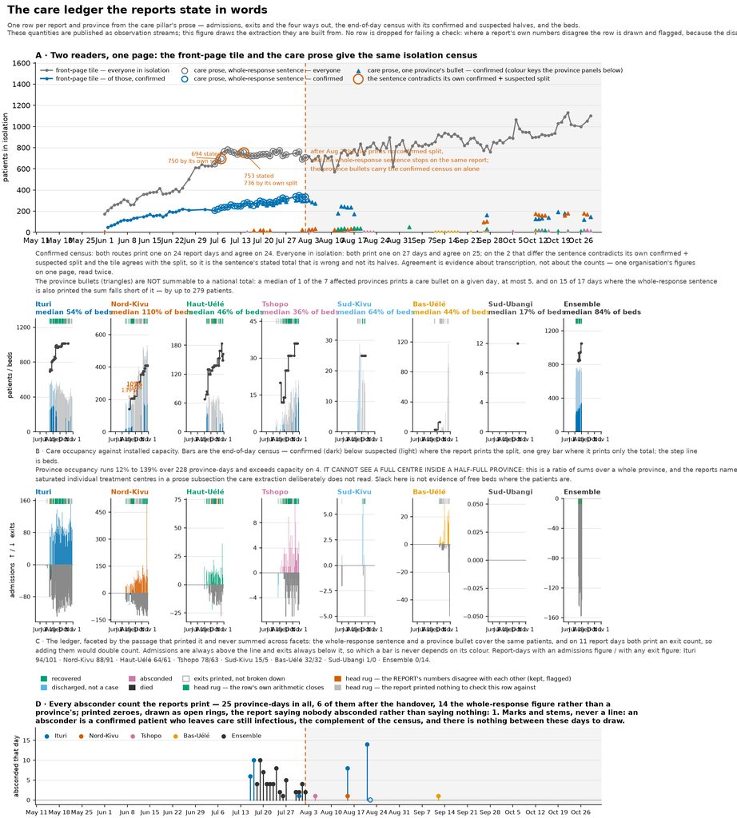

The care ledger, as the reports write it out in words. Panel A is why I trust it. The front-page tile and the care section’s sentence about the whole response are two readings of the same page, made by two different extractors in this repository, and wherever both print a census of confirmed patients in isolation, they agree exactly. Panel B is occupancy against capacity for each province. It’s a ratio of sums, so it can’t see one full centre inside a half-full province. Panel C is the ledger itself, split into panels by the passage that printed each value, and never summed across panels. Panel D is every count of absconders (patients who left a centre without being discharged) that the reports print, drawn as separate marks because that’s what the data are.